# DSC1105 Formative Assessment 4

DESQUITADO, Yuichi P.

2024-02-29

# Preliminary

Load the necessary packages and data frames needed for the formative assessment.

```r
# install.packages("tidyverse") # If not yet installed
library(tidyverse)
# install.packages("broom") # If not yet installed
library(broom)
# install.packages("MASS") # If not yet installed
library(MASS)
# Choose "mortality_by_latitude.csv" as data frame
df <- read.csv(
  "C:\\Users\\Yuichi Desquitado\\Desktop\\DSC1105\\mortality_by_latitude.csv",
  header = TRUE)
head(df)
```

```
##   latitude mortality_index temperature
## 1       50            1025        51.3
## 2       51            1045        49.9
## 3       52            1004        50.0
## 4       53             959        49.2
## 5       54             870        48.5
## 6       55             950        47.8
```

## 1. Using the [*Mortality by Latitude*](https://feuph.instructure.com/courses/30250/files/5542483/download?download_frd=1) data, make a plot of mortality index against mean average temperature. Is it hollow up or hollow down? Try to identify a transformation of one of the variables that will straighten out the relationship, and make a plot of the residuals to check for any remaining patterns.

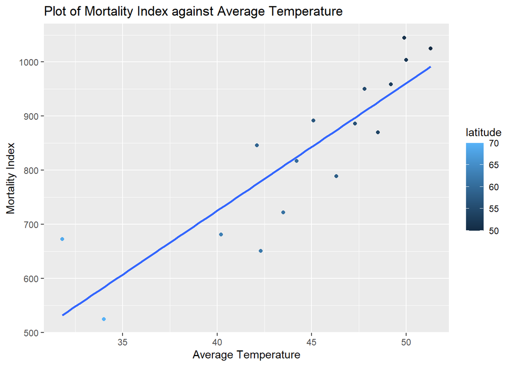

```r
model1 <- lm(
  mortality_index ~ temperature,
  data = df)

ggplot(data = df) +
  geom_point(
    mapping = aes(
      x = temperature,
      y = mortality_index,
      color = latitude)) +
  geom_smooth(
    mapping = aes(
      x = temperature,
      y = mortality_index),
    method = "lm",
    se = FALSE) +
  xlab("Average Temperature") +
  ylab("Mortality Index") +
  ggtitle("Plot of Mortality Index against Average Temperature")
```

**It is hollow up.**

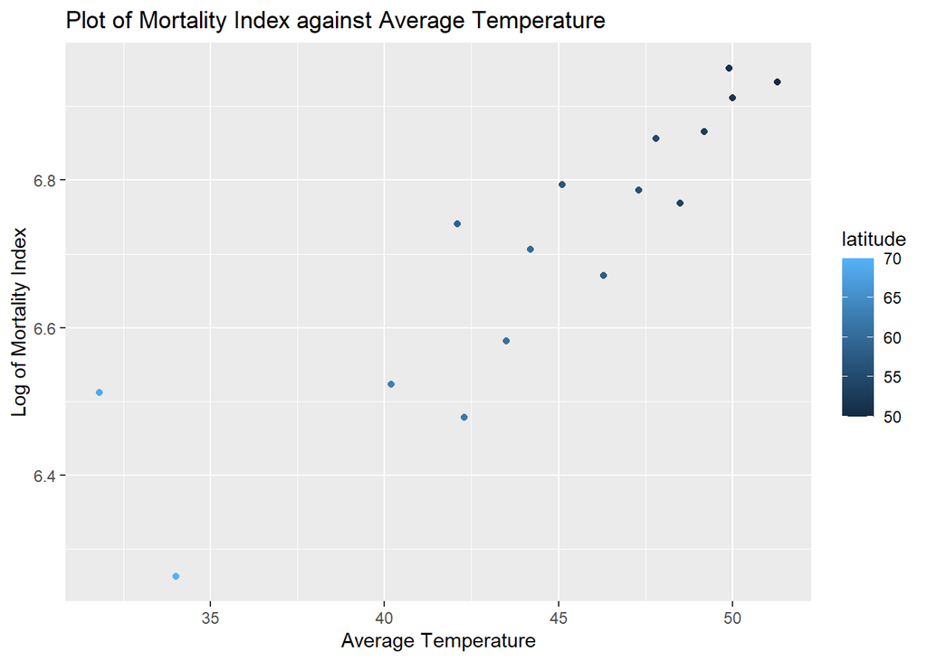

```r
# Transformation by log
ggplot(data = df) +
  geom_point(
    mapping = aes(
      x = temperature,
      y = log(mortality_index),
      color = latitude)) +
  xlab("Average Temperature") +
  ylab("Log of Mortality Index") +
  ggtitle("Plot of Mortality Index against Average Temperature")
```

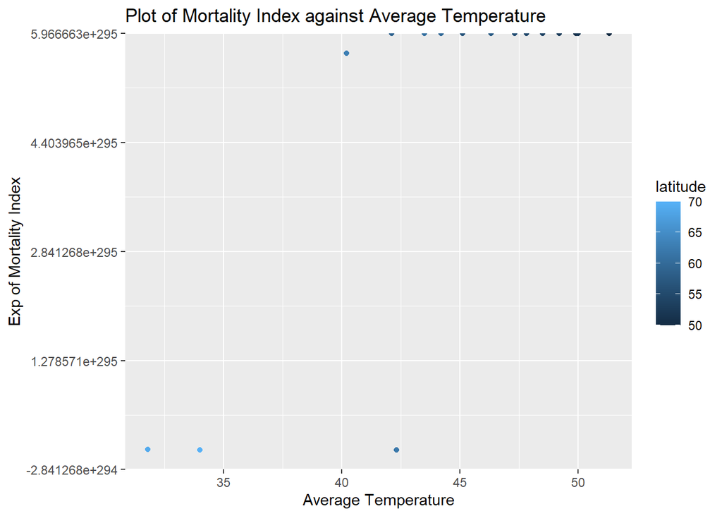

```r
# Transformation by exponentiation
ggplot(data = df) +
  geom_point(
    mapping = aes(
      x = temperature,
      y = exp(mortality_index),
      color = latitude)) +
  xlab("Average Temperature") +
  ylab("Exp of Mortality Index") +
  ggtitle("Plot of Mortality Index against Average Temperature")
```

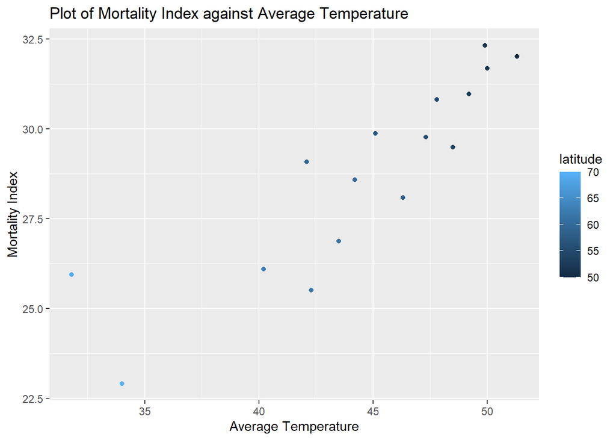

```r
# Transformation by square root
ggplot(data = df) +
  geom_point(
    mapping = aes(
      x = temperature,
      y = sqrt(mortality_index),
      color = latitude)) +
  xlab("Average Temperature") +
  ylab("Mortality Index") +
  ggtitle("Plot of Mortality Index against Average Temperature")
```

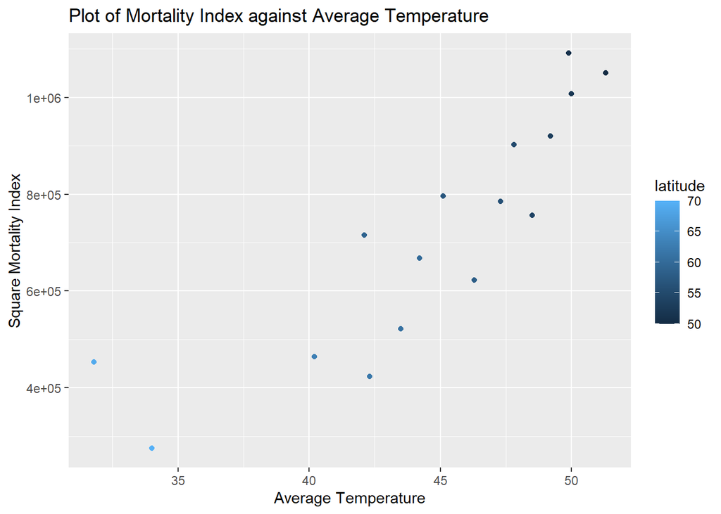

```r
# Transformation by square
ggplot(data = df) +
  geom_point(
    mapping = aes(
      x = temperature,
      y = mortality_index ** 2,
      color = latitude)) +
  xlab("Average Temperature") +
  ylab("Square Mortality Index") +
  ggtitle("Plot of Mortality Index against Average Temperature")
```

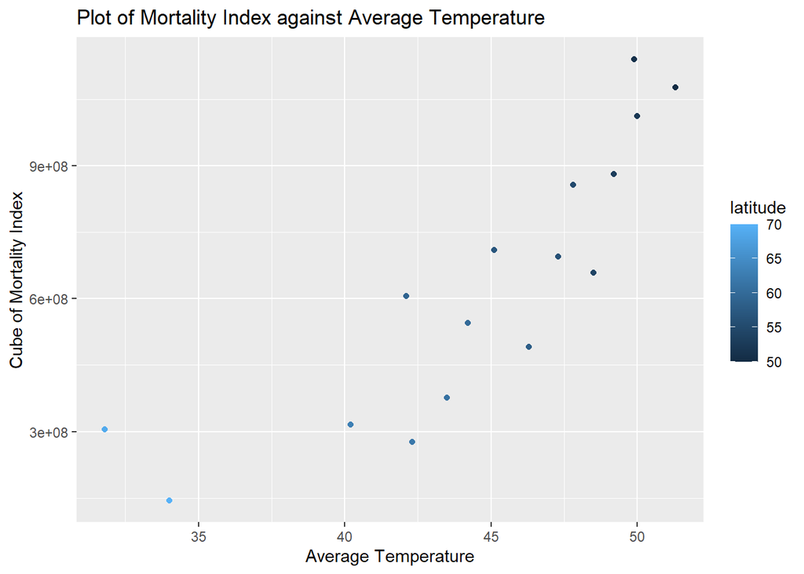

```r
# Transformation by cube
ggplot(data = df) +
  geom_point(
    mapping = aes(
      x = temperature,
      y = mortality_index ** 3,
      color = latitude)) +
  xlab("Average Temperature") +
  ylab("Cube of Mortality Index") +
  ggtitle("Plot of Mortality Index against Average Temperature")
```

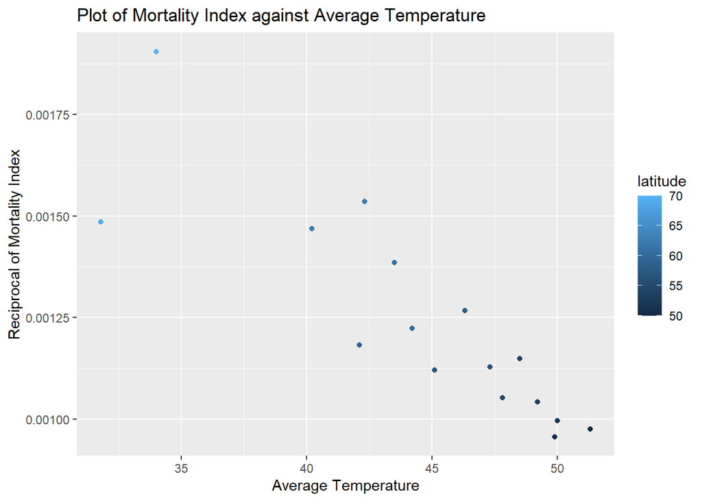

```r
# Transformation by reciprocal
ggplot(data = df) +
  geom_point(
    mapping = aes(
      x = temperature,
      y = 1 / mortality_index,
      color = latitude)) +
  xlab("Average Temperature") +
  ylab("Reciprocal of Mortality Index") +
  ggtitle("Plot of Mortality Index against Average Temperature")
```

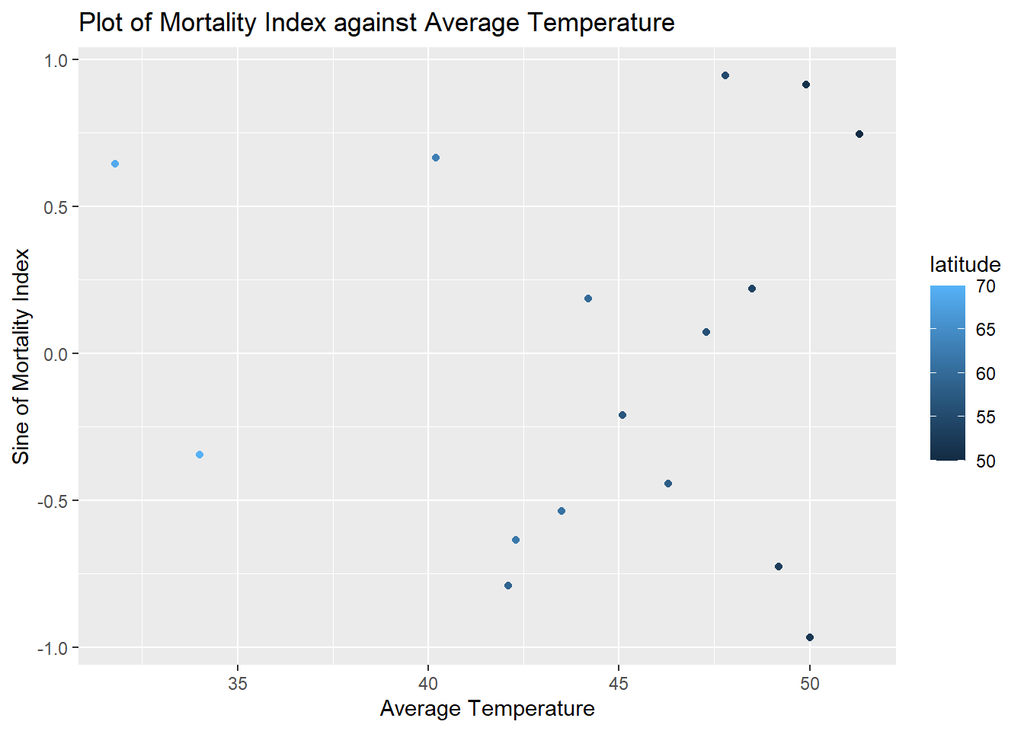

```r
# Transformation by sin
ggplot(data = df) +
  geom_point(
    mapping = aes(
      x = temperature,
      y = sin(mortality_index),
      color = latitude)) +
  xlab("Average Temperature") +
  ylab("Sine of Mortality Index") +
  ggtitle("Plot of Mortality Index against Average Temperature")
```

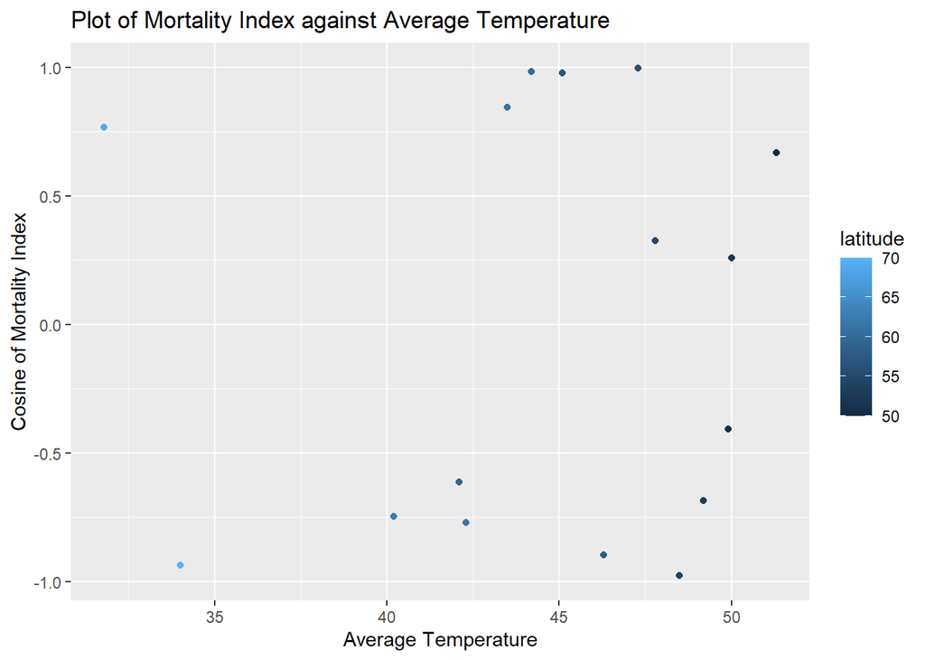

```r
# Transformation by cos
ggplot(data = df) +
  geom_point(
    mapping = aes(
      x = temperature,
      y = cos(mortality_index),
      color = latitude)) +
  xlab("Average Temperature") +
  ylab("Cosine of Mortality Index") +
  ggtitle("Plot of Mortality Index against Average Temperature")
```

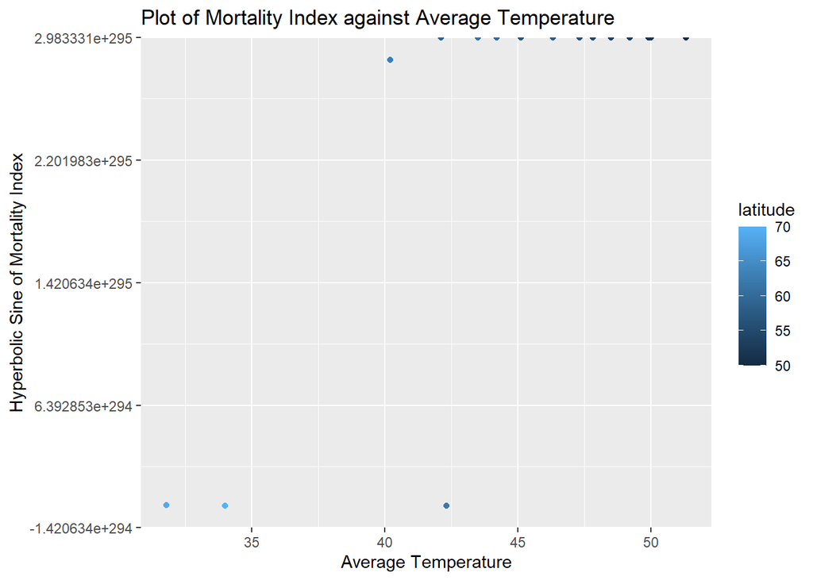

```r
# Transformation by sinh
ggplot(data = df) +
  geom_point(
    mapping = aes(
      x = temperature,
      y = sinh(mortality_index),
      color = latitude)) +
  xlab("Average Temperature") +
  ylab("Hyperbolic Sine of Mortality Index") +
  ggtitle("Plot of Mortality Index against Average Temperature")
```

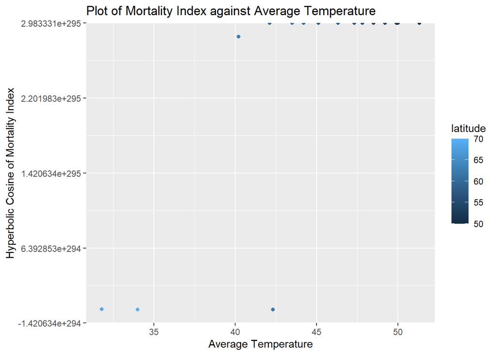

```r
# Transformation by cosh
ggplot(data = df) +
  geom_point(
    mapping = aes(
      x = temperature,
      y = cosh(mortality_index),
      color = latitude)) +
  xlab("Average Temperature") +
  ylab("Hyperbolic Cosine of Mortality Index") +
  ggtitle("Plot of Mortality Index against Average Temperature")
```

**None of the transformation gave a narrower presentation, thus none is recommended.**

## 2. Using the same subset of the diamonds dataset, make a plot of log price as a function of carat with a loess smoother. Try several values for the span and degree arguments and comment briefly about your choice.

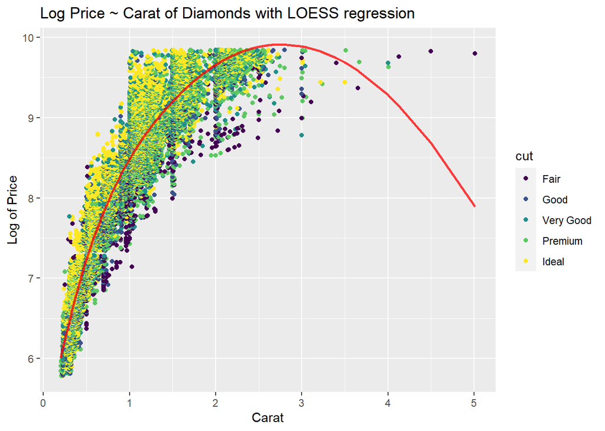

```r
# To mutate price to log(price)
diamonds <- diamonds %>%
  mutate(
    log_price = log(price))

# LOESS of log_price ~ carat
loess_diamonds <- loess(
  log_price ~ carat,
  data = diamonds)

# GGPlot via the lecture
ggplot(
  augment(
    loess_diamonds,
    data = diamonds),
  aes(
    x = carat,
    y = .fitted)) +
  geom_point(
    aes(
      y = log_price,
      color = cut)) +
  geom_line(
    color = "red",
    linewidth = 1,
    alpha = 0.75) +
  xlab("Carat") +
  ylab("Log of Price") +
  ggtitle("Log Price ~ Carat of Diamonds with LOESS regression")
```

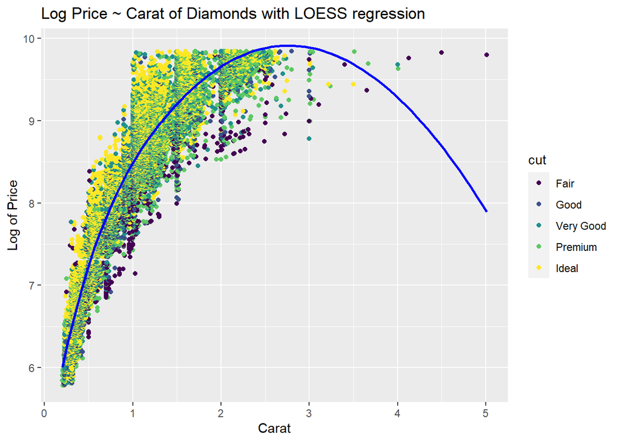

```r
# To plot the data using LOESS
ggplot(diamonds) +
  geom_point(
    aes(
      x = carat,
      y = log_price,
      color = cut)) +
  geom_smooth(
    method = "loess",
    aes(
      x = carat,
      y = log_price),
    se = FALSE,
    color = "blue",
    alpha = 0.75) +
  xlab("Carat") +
  ylab("Log of Price") +
  ggtitle("Log Price ~ Carat of Diamonds with LOESS regression")
```

## 3. Compare the fit of the loess smoother to the fit of the polynomial + step function regression using a plot of the residuals in the two models. Which one is more faithful to the data?

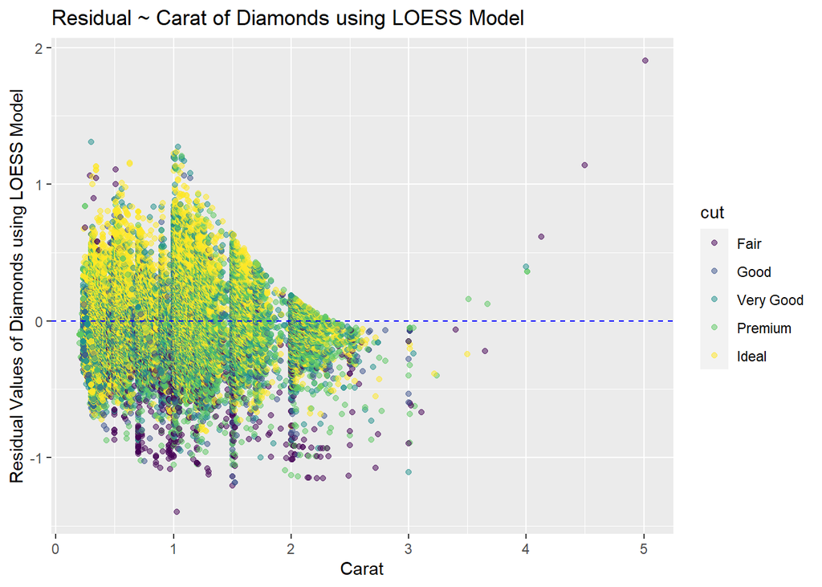

```r
# To generate model using LOESS
loess_model <- loess(
  log_price ~ carat,
  data = diamonds)

# To include LOESS residuals in the diamonds data set for later plotting
diamonds$loess_residuals <- residuals(loess_model)

# To input step for diamonds via carat
diamonds$step <- ifelse(diamonds$carat > 1, 1, 0)

# To generate Polynomial + Step residuals for diamond
poly_step_model <- lm(
  log_price ~ poly(carat, 2) + step,
  data = diamonds)

# To include the residuals of the poly + step model in the diamonds data set
diamonds$step_residuals <- residuals(poly_step_model)



ggplot(diamonds) +
  geom_point(
    aes(
      x = carat,
      y = loess_residuals,
      color = cut),
    alpha = 0.5) +
  geom_hline(
    yintercept = 0,
    linetype = "dashed",
    color = "blue") +
  xlab("Carat") +
  ylab("Residual Values of Diamonds using LOESS Model") +
  ggtitle("Residual ~ Carat of Diamonds using LOESS Model")
```

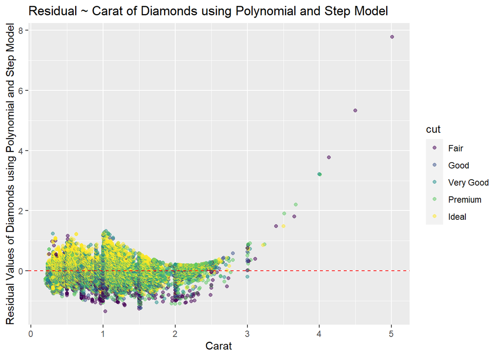

```r
ggplot(diamonds) +
  geom_point(
    aes(
      x = carat,
      y = step_residuals,
      color = cut),
    alpha = 0.5) +
  geom_hline(
    yintercept = 0,
    linetype = "dashed",
    color = "red") +
  xlab("Carat") +
  ylab("Residual Values of Diamonds using Polynomial and Step Model") +
  ggtitle("Residual ~ Carat of Diamonds using Polynomial and Step Model")
```

**LOESS model looks more faithful as the outlier is much lower than the polynomial + step. The data projected by LOESS is much compact than the other one.**